# Исследование объявлений о продаже квартир

Теперь выделим факторы, которые влияют на стоимость объекта недвижимости в центре Санкт-Петербурга. Изучим влияние числа комнат, типа этажа, удалённости от центра и даты размещения объявления.

```python
# Прежде, чем строить графики по данным, также исключим выбросы из значений столбца 'last_price'
# и сохраним таблицу без выбросов в новой переменной.

center_spb_for_calc = center_spb_df.query('last_price <= 60')
```

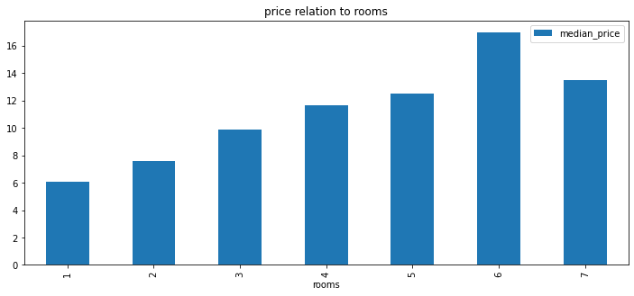

```python
# Создадим сводную таблицу и на основе её данных построим график барплот

price_to_rooms2 = center_spb_for_calc.pivot_table(index='rooms', values='last_price', aggfunc='median')
price_to_rooms2.columns = ['median_price']
price_to_rooms2['rooms'] = price_to_rooms2.index
price_to_rooms2 = price_to_rooms2.reset_index(drop=True)

price_to_rooms2.plot(kind='bar', x='rooms', y='median_price', figsize=(12, 5), title='price relation to rooms')
```

Также как и в случае с наблюдениями по всей базе недвижимости, можем отметить, что наблюдается рост медианного значения цены с ростом числа комнат.

```python
# Для типа этажа построим сводную таблицу.

center_spb_for_calc.pivot_table(index='floor_type', values='last_price', aggfunc='median').sort_values('last_price', ascending=False)
```

| floor_type | last_price |
| --- | --- |
| другой | 8.775 |
| последний | 8.300 |
| первый | 6.200 |

Как и в случае с наблюдениями по всей базе, можем отметить, что медианное значение цены объектов недвижимости в центре Санкт-Петербурга выше для этажа, который не является первым или последним и ниже — для первого этажа. Эти медианные значение почти вдвое выше, чем для наблюдений по всей базе.

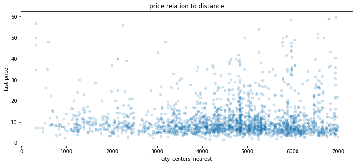

```python
center_spb_for_calc.plot(x='city_centers_nearest', y='last_price', kind='scatter', alpha=0.2, figsize=(12, 5), title='price relation to distance')
```

```python
center_spb_for_calc['last_price'].corr(center_spb_for_calc['city_centers_nearest'])
```

```
0.04008014142029807
```

```python
# Используем сводную таблицу, чтобы оценить медианное значение цены, на объекты недвижимости, выставленные
# на продажу в разные дни недели

center_spb_for_calc.pivot_table(index='weekday', values='last_price', aggfunc='median').sort_values('last_price', ascending=False)
```

| weekday | last_price |
| --- | --- |
| 1 | 8.600 |
| 7 | 8.589 |
| 3 | 8.500 |
| 5 | 8.400 |
| 2 | 8.300 |
| 6 | 8.010 |
| 4 | 7.971 |

Как и в случае с наблюдениями по всей базе недвижимости, видим отсутствие явных различий между днями недели, в которые были выставлены объекты недвижимости и их стоимостью. Здесь лидером по значению медианы является понедельние: 8,6 миллиона (значение лидера медианы по всей выборки было равно 4.6 миллионам и тогда это был вторник). Объявления, выставленные в четверг имеют наименьшее значение медианной стоимости — 7,9 миллионов (в прошлый раз аутсайдером была суббота со значением 4.45 миллионов). Как и в прошлый раз, мы можем утверждать, что различия невелики. На основе данных из сводной таблицы можем построить линейный график, чтобы увидеть как ведут себя медианные значения выставляемых объявлений о продаже недвижимости в течение недели.

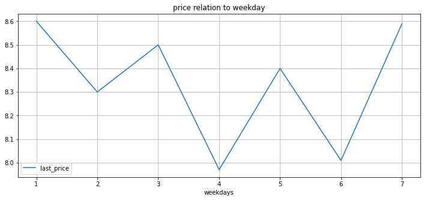

```python
weekday_distribution2 = center_spb_for_calc.pivot_table(index='weekday', values='last_price', aggfunc='median').sort_values('last_price', ascending=False)
weekday_distribution2['weekdays'] = weekday_distribution2.index
weekday_distribution2.sort_values('weekdays').plot(x='weekdays', y='last_price', figsize=(12, 5), grid=True, title='price relation to weekday')
```

Линейный график медианных значений стоимости объектов недвижимости, расположенных в центре Санкт-Петербурга, выставленных в разные дни отличается от линейного графика медианных значений стоимости по всей базе недвижимости. Настоящий график более острый. Это говорит о том, что зависимость отсутствует полностью: каждый день не похож на предыдущий день недели.

```python
# Попытаемся оценить зависимость между месяцем публикации объявления и ценой объекта недвижимости в центре СПБ.

center_spb_for_calc.pivot_table(index='month', values='last_price', aggfunc='median').sort_values('last_price', ascending=False)
```

| month | last_price |
| --- | --- |
| 11 | 8.7500 |
| 08 | 8.5945 |
| 01 | 8.5000 |
| 02 | 8.5000 |
| 03 | 8.5000 |
| 09 | 8.5000 |
| 07 | 8.4950 |
| 10 | 8.3135 |
| 04 | 8.2000 |
| 05 | 7.9040 |
| 06 | 7.8000 |
| 12 | 7.7000 |

Мы помним, что в сводной таблице, построенной по всей базе лидером по значению медианной стоимости был месяц апрель. Сейчас апрель близок к аутсайдерам по своему значению медианы. Вместе с маем, июнем и декабрём он занимает последние строки «рейтинга популярных месяцев». Лидером является ноябрь, на втором месте август, а на третьем — январь. Есть подозрение, что линейный график получится более ломанным, чем в случае с наблюдениями по всей базе недвижимости. Проверим, подтвердятся ли подозрения.

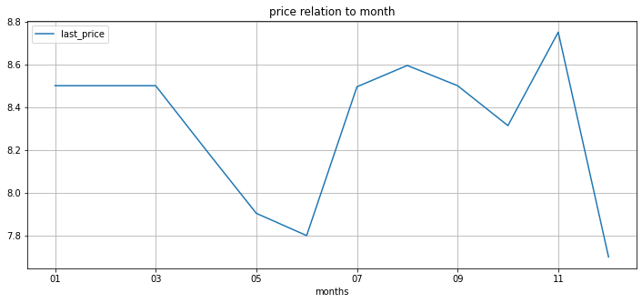

```python
month_distribution2 = center_spb_for_calc.pivot_table(index='month', values='last_price', aggfunc='median').sort_values('last_price', ascending=False)
month_distribution2['months'] = month_distribution2.index
month_distribution2.sort_values('month').plot(x='months', y='last_price', figsize=(12, 5), grid=True, title='price relation to month')
```

На этом линейном графике видно, что первые три месяца года отличаются стабильностью, после которой следует падение медианного значения цены с последующим ростом после июня месяца. Видно, что направление графика часто меняется. Можно утверждать о том, что зависимости цены от месяца нет, но июнь стабильно является месяцем с низким значением медианы как в наблюдениях по всей базе недвижимости, так и в наблюдениях по объектам недвижимости, расположенным в центре Санкт-Петербурга.

```python
# Попробуем увидеть зависимость между годом, в котором был выставлен на продажу объект недвижимости в центре
# Санкт-Петербурга и его ценой.

center_spb_for_calc.pivot_table(index='year', values='last_price', aggfunc='median').sort_values('last_price', ascending=False)
```

| year | last_price |
| --- | --- |
| 2014 | 16.200 |
| 2019 | 8.945 |
| 2015 | 8.600 |
| 2016 | 8.340 |
| 2017 | 8.200 |
| 2018 | 8.100 |

Как и в случае с наблюдениями по всей базе недвижимости, 2014-й год — абсолютный лидер по показателю медианного значения стоимости объектов недвижимости. Вероятно, дело в кризисе, который произошёл в тот год :) Посмотрим, как ведут себя эти данные на линейном графике.

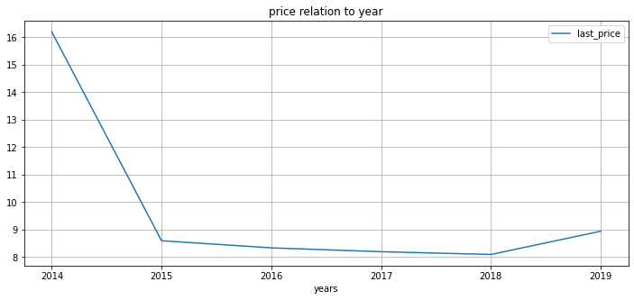

```python
year_distribution2 = center_spb_for_calc.pivot_table(index='year', values='last_price', aggfunc='median').sort_values('last_price', ascending=False)
year_distribution2['years'] = year_distribution2.index
year_distribution2.sort_values('years').plot(x='years', y='last_price', figsize=(12, 5), grid=True, title='price relation to year')
```

# 5 Общий вывод

В результате проведённого исследования были изучены распределения значений площади, цены, числа комнат и высоты потолков объектов недвижимости по всей базе недвижимости и отдельно по объектам недвижимости, расположенным в центре Санкт-Петербурга.

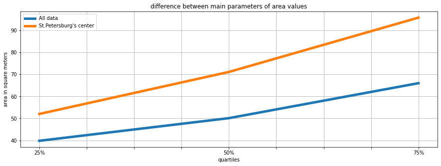

```python
all_data_area = df['total_area'].describe()[4:7]
spb_center_area = center_spb_df['total_area'].describe()[4:7]

ax = all_data_area.plot(legend=True,
                        linewidth=5,
                       label='All data')

spb_center_area.plot(ax=ax,
                figsize=(15, 5),
                linewidth=5,
                grid=True,
                label = "St.Petersburg's center",
                legend=True,
                xlabel='quartiles',
                ylabel='area in square meters',
                title='difference between main parameters of area values')
```

Значения площади квартир в центре Санкт-Петербурга выше, чем значения по всей базе недвижимости. На графике можно увидеть сравнение значений первого, второго и третьего квартилей. Можно заметить, что от первого к третьему квартилю увеличивается разрыв в значениях. Медианное значение объекта недвижимости по всей базе равно 50 квадратным метрам, тогда как по объектам недвижимости в центре Санкт-Петербурга — превышает значение в 70 квадратных метров.

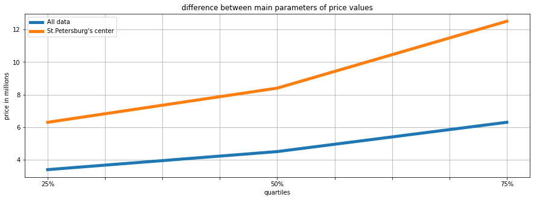

```python
all_data_price = df['last_price'].describe()[4:7]
spb_center_price = center_spb_df['last_price'].describe()[4:7]

ax = all_data_price.plot(legend=True,
                        linewidth=5,
                       label='All data')

spb_center_price.plot(ax=ax,
                figsize=(15, 5),
                linewidth=5,
                grid=True,
                label = "St.Petersburg's center",
                legend=True,
                xlabel='quartiles',
                ylabel='price in millions',
                title='difference between main parameters of price values')
```

Значения цен в центре Санкт-Петербурга так же выше, чем значения цен по всей базе недвижимости. Медиана, рассчитанная по значениям объектов недвижимости центра Санкт-Петербурга превосходит медиану всей базы почти вдвое. Очевидно, что квартиры в центре дороже. Также как и в случае с площадью объектов недвижимости можем наблюдать увеличение разрыва между линиями графиков о первого квартиля к третьему.

Самыми популярными вариантами объектов недвижимости во всей базе являются однушки и по мере увеличения числа комнат количество объявлений уменьшается, тогда как в случае с центром Санкт-Петербурга наиболее популярные варианты это двух- и трёхкомнатные объекты недвижимости: они сильно популярнее, чем однокомнатные и четырёхкомнатные, между которыми, в свою очередь разрыв незначителен. Покажем это с помощью графиков пайчарт.

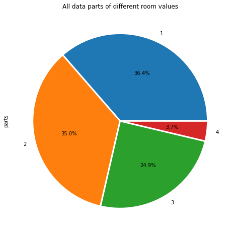

```python
all_data_rooms = df.query('rooms <= 4').pivot_table(index='rooms', values='last_price', aggfunc='count')
all_data_rooms.columns = ['count']
all_data_rooms.plot(kind='pie',
                    y='count',
                    figsize=(8, 8),
                    autopct='%.1f%%',
                    wedgeprops={'linewidth': 3.0, 'edgecolor': 'white'},
                    legend=False,
                    title='All data parts of different room values',
                    label='parts')
```

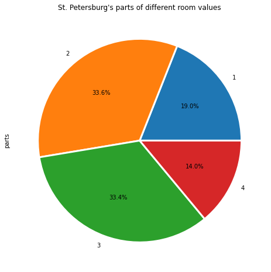

```python
spb_center_rooms = center_spb_df.query('rooms <= 4').pivot_table(index='rooms', values='last_price', aggfunc='count')
spb_center_rooms.columns = ['count']
spb_center_rooms.plot(kind='pie',
                      y='count',
                      figsize=(8, 8),
                      autopct='%.1f%%',
                      wedgeprops={'linewidth': 3.0, 'edgecolor': 'white'},
                      legend=False,
                      label='parts',
                      title="St. Petersburg's parts of different room values")
```

Значения высоты потолков в центре Санкт-Петербурга так же выше, чем значения цен по всей базе недвижимости. Вторым по популярности вариантом высоты потолков во всей базе является значение 2.5 метра, тогда как в центре Санкт-Петербурга второй вариант — это 3 метра. Посмотрим, как отличаются квартили распределения с помощью линейных графиков.

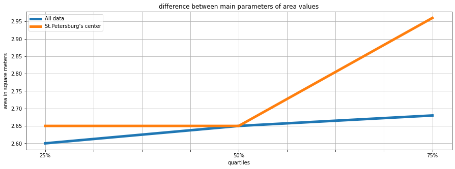

```python
all_data_ceiling_height = df['ceiling_height'].describe()[4:7]
spb_center_celing_height = center_spb_df['ceiling_height'].describe()[4:7]

ax = all_data_ceiling_height.plot(legend=True,
                        linewidth=5,
                       label='All data')

spb_center_celing_height.plot(ax=ax,
                figsize=(15, 5),
                linewidth=5,
                grid=True,
                label = "St.Petersburg's center",
                legend=True,
                xlabel='quartiles',
                ylabel='area in square meters',
                title='difference between main parameters of area values')
```

На графике видно, что медианные значения, рассчитанные по объектам всей базы недвижимости и по объектам в центре Санкт-Петербурга совпадают, первые квартили различаются незначительно (всего на пять сантиметров), тогда как основной разрыв виден на третьем квартиле. Это говорит о том, что в центре Санкт-Петербурга доля объектов недвижимости с потолками, чьи значения стремятся к значению в 3 метра примерно такая же, как и доля объектов по всей базе, чьи значения стремятся к значению в 2.7 метра. Потолки в центре Санкт-Петербурга выше.

## Чек-лист готовности проекта

Поставьте 'x' в выполненных пунктах. Далее нажмите Shift+Enter.

- [x] открыт файл
- [ ] файлы изучены (выведены первые строки, метод `info()`)
- [ ] определены пропущенные значения
- [ ] заполнены пропущенные значения
- [ ] есть пояснение, какие пропущенные значения обнаружены
- [ ] изменены типы данных
- [ ] есть пояснение, в каких столбцах изменены типы и почему
- [ ] посчитано и добавлено в таблицу: цена квадратного метра
- [ ] посчитано и добавлено в таблицу: день недели, месяц и год публикации объявления
- [ ] посчитано и добавлено в таблицу: этаж квартиры; варианты — первый, последний, другой
- [ ] посчитано и добавлено в таблицу: соотношение жилой и общей площади, а также отношение площади кухни к общей
- [ ] изучены следующие параметры: площадь, цена, число комнат, высота потолков
- [ ] построены гистограммы для каждого параметра
- [ ] выполнено задание: «Изучите время продажи квартиры. Постройте гистограмму. Посчитайте среднее и медиану. Опишите, сколько обычно занимает продажа. Когда можно считать, что продажи прошли очень быстро, а когда необычно долго?»
- [ ] выполнено задание: «Уберите редкие и выбивающиеся значения. Опишите, какие особенности обнаружили».
- [ ] выполнено задание: «Какие факторы больше всего влияют на стоимость квартиры? Изучите, зависит ли цена от квадратного метра, числа комнат, этажа (первого или последнего), удалённости от центра. Также изучите зависимость от даты размещения: дня недели, месяца и года».
- [ ] выполнено задание: «Выберите 10 населённых пунктов с наибольшим числом объявлений. Посчитайте среднюю цену квадратного метра в этих населённых пунктах. Выделите населённые пункты с самой высокой и низкой стоимостью жилья. Эти данные можно найти по имени в столбце `locality_name`».
- [ ] выполнено задание: «Изучите предложения квартир: для каждой квартиры есть информация о расстоянии до центра. Выделите квартиры в Санкт-Петербурге (`locality_name`). Ваша задача — выяснить, какая область входит в центр. Создайте столбец с расстоянием до центра в километрах: округлите до целых значений. После этого посчитайте среднюю цену для каждого километра. Постройте график: он должен показывать, как цена зависит от удалённости от центра. Определите границу, где график сильно меняется — это и будет центральная зона».
- [ ] выполнено задание: «Выделите сегмент квартир в центре. Проанализируйте эту территорию и изучите следующие параметры: площадь, цена, число комнат, высота потолков. Также выделите факторы, которые влияют на стоимость квартиры (число комнат, этаж, удалённость от центра, дата размещения объявления). Сделайте выводы. Отличаются ли они от общих выводов по всей базе?»
- [ ] в каждом этапе есть выводы
- [ ] есть общий вывод